# Statistics with Python - 1

# (Univariate)

### What is Statistics ?

#### 1. Statistics is the discipline that concerns the collection, organization, analysis, interpretation, and presentation of data

#### 2. We want to make inferential statements about well defined target population

#### 3. Well defined target population:

- Children born in India in year 2020.
- Employees of GE Healthcare on 19th December, 2020.
- Male population of Bangalore at a particular date and time.
- Women with Bachelor’s degree in engineering in India on a particular date.
- Bolts produced in XYZ manufacturing unit on a particular day.

### How to get information about population ?

- **Conduct a census:** We collect data about each individual/unit of population explicitly. Difficult, time-consuming and expensive exercise in most cases.
- **Draw a sample** from population and collect data about all units in the sample
- Scientific Probability Sample
- Non-Probability Sample
- **Simple Random Sampling** is a type of scientific probability sampling where each unit has equal probability of selection.

### Is data i.i.d. ?

- i.i.d : Independent and identically distributed
- If sample is i.i.d, it represents population
- Given i.i.d. sample we can estimate features of population distribution
- Mean
- Median
- Mode
- Range and interquartile range (IQR)
- Percentile and quartiles
- Variance
- Standard Deviation

### Variable Types

1. **Categorical**
   1. **Ordinal**-Groups have an order or ranking e.g. educational experience - elementary school graduate, high school graduate, college graduate.
   2. **Nominal**-Groups are merely names, no ranking e.g. hair color - black, blonde, brown, brunette, red etc.
2. **Quantitative**
   1. **Continuous**-Could take on any value within an interval,many possible values e.g. height of people
   2. **Discrete**-Countable value, finite number of values e.g. number of members in families

### Tables, Bar Charts and Pie Charts for Categorical Variables

|  | Id | Gender | Race | Marital_Status |
| --- | --- | --- | --- | --- |
| 0 | 83732 | Male | Non-Hispanic White | Married |
| 1 | 83733 | Male | Non-Hispanic White | Divorced |
| 2 | 83734 | Male | Non-Hispanic White | Married |
| 3 | 83735 | Female | Non-Hispanic White | Living with partner |
| 4 | 83736 | Female | Non-Hispanic Black | Divorced |
| ... | ... | ... | ... | ... |
| 5730 | 93695 | Female | Non-Hispanic White | Widowed |
| 5731 | 93696 | Male | Non-Hispanic White | Married |
| 5732 | 93697 | Female | Non-Hispanic White | Widowed |
| 5733 | 93700 | Male | Non-Hispanic White | Married |
| 5734 | 93702 | Female | Non-Hispanic White | Never married |

5735 rows × 4 columns

|  | Gender | Count |
| --- | --- | --- |
| 0 | Male | 2759 |
| 1 | Female | 2976 |

```
5
```

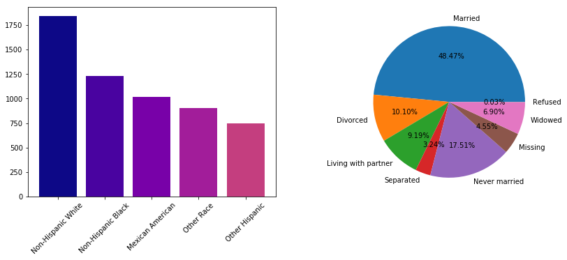

S/H

```python
import pandas as pd
import numpy as np
import matplotlib.pyplot as plt
import matplotlib
import Toggle
from collections import Counter
pd.set_option('display.max_rows', 10)
df = pd.read_csv('dataSet.csv')
df = df.rename(columns={"SEQN":"Id","RIAGENDR":"Gender","RIDRETH1":"Race","DMDMARTL":"Marital_Status"})
gen_dict = {1: "Male", 2: "Female"}
race_dict = {1:"Mexican American",2:"Other Hispanic",3:"Non-Hispanic White",4:"Non-Hispanic Black",5:"Other Race"}
marital_dict = {1:"Married",2:"Widowed",3:"Divorced",4:"Separated",5:"Never married",
                6:"Living with partner",77:"Refused",99:"Don't Know",np.nan:"Missing"}
df = df.replace({"Gender": gen_dict,"Race":race_dict,"Marital_Status":marital_dict})
display(df[['Id','Gender','Race','Marital_Status']])
a = Counter(df['Gender'].values)
df1 = pd.DataFrame(a.items(), columns=['Gender', 'Count'])
display(df1)
fig, axis = plt.subplots(1, 2,figsize=(14,5))
cmap1 = matplotlib.cm.get_cmap('plasma')
#print(type(cmap1))
#print(cmap1.colors)
b = Counter(df['Race'].values)
print(len(b.keys()))
colorLst = [cmap1.colors[30*i] for i in range(len(b.keys()))]
axis[0].bar(b.keys(),b.values(),color=colorLst)
axis[0].tick_params(axis='x', labelrotation = 45)
c = Counter(df['Marital_Status'].values)
axis[1].pie(c.values(), labels = c.keys(),autopct='%1.2f%%')
plt.show()
Toggle.hide_toggle()
```

### What you do when you get data on a quantiative variable ?

Suppose you get ages of all persons working in your company. What you do with it to begin analysis? Plot a **Histogram** !!!

|  | EmpId | Age |
| --- | --- | --- |
| 0 | 83732 | 62 |
| 1 | 83733 | 53 |
| 2 | 83734 | 78 |
| 3 | 83735 | 56 |
| 4 | 83736 | 42 |
| ... | ... | ... |
| 5730 | 93695 | 76 |
| 5731 | 93696 | 26 |
| 5732 | 93697 | 80 |
| 5733 | 93700 | 35 |
| 5734 | 93702 | 24 |

5735 rows × 2 columns

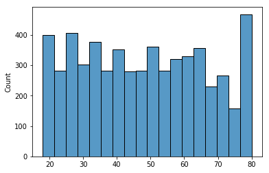

S/H

```python
import pandas as pd
import seaborn as sns
import matplotlib.pyplot as plt
pd.set_option('display.max_rows', 10)
df = pd.read_csv('dataSet.csv')
df = df.rename(columns={"SEQN":"EmpId","RIDAGEYR":"Age"})
display(df[['EmpId','Age']])
sns.histplot(df['Age'].values,kde=False)
plt.show()
Toggle.hide_toggle()
```

$Variance = var(X) = cov(X,X) = \sigma_X^2 = \frac{\sum_{i=1}^{N}(x_i-\bar{x})^2}{N}$  
$Standard Deviation = \sqrt{var (X)} = \sigma_X$

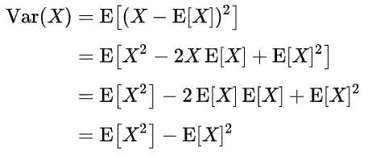

If there is a finite population of size N, $var(X) = \frac{\sum_{i=1}^{N}(x_i-\bar{x})^2}{N}$  
If we have a sample of size N from the population, $var(X) = \frac{\sum_{i=1}^{N}(x_i-\bar{x})^2}{N-1}$ (unbiased estimate of population variance)

### Getting Insights from Histogram

#### Characteristics of Histogram

1. **Shape:** Overall appearance of the histogram. E.g. symmetric, bell-shaped, left-skewed, right-skewed, unimodal, bimodal etc.
2. **Centre:** Mean/Median
3. **Spread:** How far data spreads. Range, interquartile range, standard deviation, variation
4. **Outliers:** Data points that are far from the bulk of data.

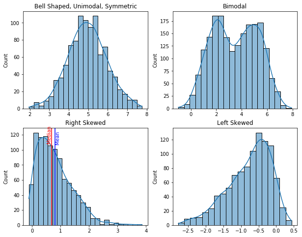

S/H

```python
import numpy as np
import matplotlib.pyplot as plt
import seaborn as sns
from scipy.stats import skewnorm
from scipy import stats
import statistics
import Toggle
np.random.seed(0)
figure, axis = plt.subplots(2, 2,figsize=(10,8))
x = np.random.normal(loc=5.0, scale=1.0, size=1000)
sns.histplot(x,kde=True,ax=axis[0,0])
axis[0,0].set_title('Bell Shaped, '+ 'Unimodal, ' + 'Symmetric')

x1 = np.random.normal(loc=2.0, scale=1.0, size=1000)
x2 = np.random.normal(loc=5.0, scale=1.0, size=1000)
sns.histplot(list(x1)+list(x2),kde=True,ax=axis[0,1])
axis[0,1].set_title('Bimodal')

a = 15
x3 = skewnorm.rvs(a, size=1000)
mean = np.round(np.mean(x3),4)
median = np.round(np.median(x3),4)
sns.histplot(x3,kde=True,ax=axis[1,0])
axis[1,0].set_title('Right Skewed')
axis[1,0].axvline(x=mean,color='blue')
axis[1,0].axvline(x=median,color='red')
axis[1,0].text(mean, 120, 'Mean', fontsize = 10, rotation=90, color='blue')
axis[1,0].text(median-0.16, 127, 'Median', fontsize = 10, rotation=90, color='red')
#x1 = np.random.uniform(-3,5,size=50)
#x2 = np.random.uniform(0,5,size=100)
#x3 = np.random.uniform(3,5,size=400)
#sns.histplot(list(x1)+list(x2) + list(x3),kde=True,ax=axis[1,0])

a = -5
x4 = skewnorm.rvs(a, size=1000)
sns.histplot(x4,kde=True,ax=axis[1,1])
axis[1,1].set_title('Left Skewed')

plt.show()
Toggle.hide_toggle()
```

### Getting Insights from Box Plot, Violin Plot and Summary Statistics

- Box Plot is also know as Box & Whisker Plot
- IQR = Q<sub>3</sub> - Q<sub>1</sub> (Interquartile Range)
- Outliers > Q<sub>3</sub> + 1.5*IQR
- Outliers < Q<sub>1</sub> - 1.5*IQR
- Whisker end points: Largest value less than Q<sub>3</sub> + 1.5*IQR and Smallest value greater than Q<sub>1</sub> - 1.5*IQR

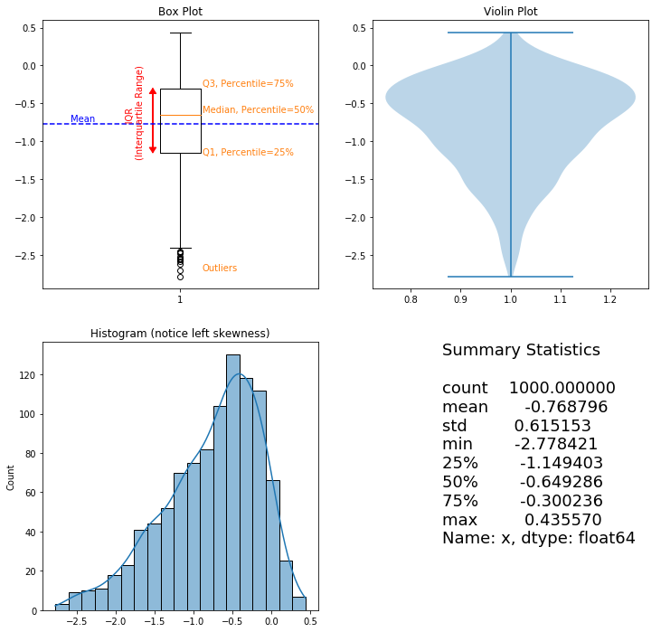

S/H

```python
import pandas as pd
import matplotlib.pyplot as plt
import matplotlib.patches as patches
df = pd.DataFrame(columns=['x'])
df['x'] = x4
D = df['x'].describe()
#print(D)
figure, axis = plt.subplots(2, 2,figsize=(12,12))
mean = D[1]

axis[0,0].axhline(y=mean,color='blue',linestyle='--')
axis[0,0].text(1.08,D[5]+0.03,'Median, Percentile=50%',color='tab:Orange')
axis[0,0].text(1.08,D[4]-0.03,'Q1, Percentile=25%',color='tab:Orange')
axis[0,0].text(1.08,D[6]+0.03,'Q3, Percentile=75%',color='tab:Orange')
axis[0,0].text(1.08,D[3]+0.07,'Outliers',color='tab:Orange')
axis[0,0].arrow(0.9,D[4],0,D[6]-D[4], color='red',head_length = 0.07, head_width = 0.025, length_includes_head = True)
axis[0,0].arrow(0.9,D[6],0,-D[6]+D[4], color='red',head_length = 0.07, head_width = 0.025, length_includes_head = True)
axis[0,0].text(0.80,D[6]+0.08, '             IQR \n(Interquartile Range)', fontsize = 10, rotation=90, color='red')
axis[0,0].text(0.6,mean+0.03,'Mean',color='blue')
axis[0,0].boxplot(df['x'])
axis[0,0].set_title('Box Plot')

axis[0,1].violinplot(df['x'])
axis[0,1].set_title('Violin Plot')

sns.histplot(x4,kde=True,ax=axis[1,0])
axis[1,0].set_title('Histogram (notice left skewness)')

axis[1,1].text(0.25,0.25,'Summary Statistics\n\n'+str(D),fontsize='18')
axis[1,1].axis('off')
plt.show()
Toggle.hide_toggle()
```

### Types of Distribution

#### Continuous Distribution

- **Uniform Distribution**

$  
 f(x) = \frac{1}{(b-a)}\\  
 b=Upper Limit\\  
 a=Lower Limit\\  
 $

- **Normal Distribution**

$  
 f(x) = \frac{1}{\sigma\sqrt{2\pi}}\exp\left( -\frac{1}{2}\left(\frac{x-\mu}{\sigma}\right)^{\!2}\,\right)\\  
 \sigma = Standard Deviation\\  
 \mu = Mean\\  
 $

- **Exponential Distribution**

$f(x)=\frac{1}{\mu}{e}^{\frac{-x}{\mu}} \qquad \qquad 0\le x < \infty $  
$\mu = Mean$

- **Cauchy Distribution**

$  
 f(x) = \frac{1}{\pi\gamma\left[1 + \left(\frac{x-\mu}{\gamma}\right)^2\right]} \qquad \qquad -\infty < x < \infty \\  
 \mu = Median\\  
 \gamma = Scale\\  
 $

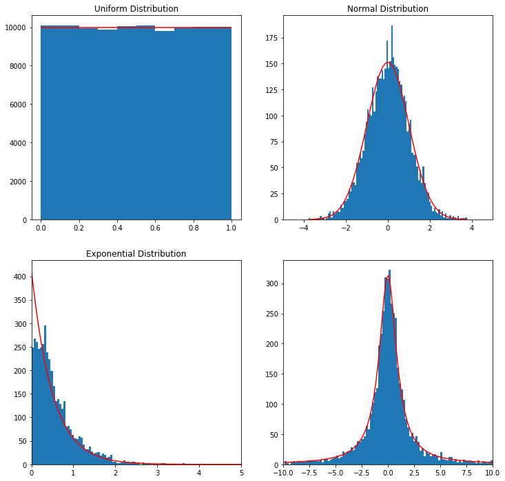

S/H

```python
import math
figure, axis = plt.subplots(2, 2,figsize=(12,12))
def acceptWithProb(p):
    a = np.random.uniform(low=0.0,high=1.0,size=1)[0]
    if(a<p):
        return True
    else:
        return False

np.random.seed(0)

X = np.random.uniform(low=0.0,high=1.0,size=100000)
#print(np.shape(X))
#print('Theoretically Mean %f'%0.5)
#print('Theoretically Variance %f'%(1/12))
#print('Actual Mean %f'%np.mean(X))
#print('Actual Variance %f'%np.var(X))
H = axis[0,0].hist(X,bins=10)
#sns.histplot(X,kde=True,stat='count',ax=axis[0,0])
f = sum(H[0])/len(H[0])
axis[0,0].hlines(y=f,color='red',xmin=0,xmax=1,label='hello')
axis[0,0].set_title('Uniform Distribution')

def normalDistProb(x,m,s):
    p = np.exp(-(((x-m)*(x-m))/(2*s*s)))/(s*math.sqrt(2*math.pi))
    return p

X = np.random.uniform(low=-10.0,high=10.0,size=100000)

m = 0
s = 1
Y = []
for i in range(len(X)):
    p = normalDistProb(X[i],m,s)
    if(acceptWithProb(p)):
        Y.append(X[i])

#t = np.arange(-10,10,0.2)
#v = normalDistProb(t,m,s)
#print(np.shape(Y))
#print('Theoretically Mean %f'%m)
#print('Theoretically Variance %f'%s*s)
#print('Actual Mean %f'%np.mean(Y))
#print('Actual Variance %f'%np.var(Y))
H = axis[0,1].hist(Y,bins=100)
v = normalDistProb(H[1],m,s)
f = sum(H[0])/sum(v)
axis[0,1].plot(H[1],f*v,color='red',label='hello')
axis[0,1].set_xlim(-5,5)
axis[0,1].set_title('Normal Distribution')

def exponentialDistProb(x,u):
    p = u*np.exp(-(u*x))
    return p

X = np.random.uniform(low=0.0,high=20.0,size=100000)

u = 2
Y = []
for i in range(len(X)):
    p = exponentialDistProb(X[i],u)
    if(acceptWithProb(p)):
        Y.append(X[i])

#t = np.arange(0,10,0.2)

#print(np.shape(Y))
#print('Theoretically Mean %f'%(1/u))
#print('Theoretically Variance %f'%(1/(u*u)))
#print('Actual Mean %f'%np.mean(Y))
#print('Actual Variance %f'%np.var(Y))
H = axis[1,0].hist(Y,bins=100)
v = exponentialDistProb(H[1],u)
f = sum(H[0])/sum(v)
axis[1,0].plot(H[1],f*v,color='red')
axis[1,0].set_xlim(0,5)
axis[1,0].set_title('Exponential Distribution')

def cauchyDistProb(x,m,g):
    p = (1/(math.pi*g))*((g*g)/((x-m)*(x-m)+g*g))
    return p

X = np.random.uniform(low=-10.0,high=10.0,size=100000)

m = 0
g = 1
Y = []
for i in range(len(X)):
    p = cauchyDistProb(X[i],m,g)
    if(acceptWithProb(p)):
        Y.append(X[i])


#t = np.arange(-10,10,0.2)
#v = cauchyDistProb(t,m,g)
#print(np.shape(Y))
#print('Theoretically Mean : Not defined. But it should be %f by symmetry'%m)
#print('Theoretically Variance: Not defined')
#print('Actual Mean %f'%np.mean(Y))
#print('Actual Variance %f'%np.var(Y))
H = axis[1,1].hist(Y,bins=100)
v = cauchyDistProb(H[1],m,g)
f = sum(H[0])/sum(v)
axis[1,1].plot(H[1],f*v,color='red')
axis[1,1].set_xlim(-10,10)
plt.show()


plt.show()
Toggle.hide_toggle()
```

#### Discrete Distribution

- **Bernoulli Distribution**

Two possible outcomes (1 or 0)  
$  
 Pr(X=1) = p\\  
 Pr(X=0) = 1-p\\  
 $

- **Binomial Distribution**

Number of successes in a sequence of n independent trials, each trial with binary outcome (1 or 0), with probability of success being p  
$  
 Pr(X=k) = {n \choose k}p^k (1-p)^{(n-k)}  
 $

- **Poisson Distribution**

Expresses the probability of a given number of events occurring in a fixed interval of time or space if these events occur with a known constant mean rate and independently of the time since the last event. The Poisson distribution is also the limit of a binomial distribution, for which the probability of success for each trial equals λ divided by the number of trials, as the number of trials approaches infinity.  
$  
 P\left( x \right) = \frac{{e^{ - \lambda } \lambda ^x }}{{x!}} \qquad \qquad x=0, 1,2,\ldots \, .  
 $

- **Geometric Distribution**

The probability distribution of the number X of Bernoulli trials needed to get one success, supported on the set { 1, 2, 3, ... }  
 $  
 f(x) = p(1 - p) ^ {x-1} \qquad \qquad x=1,2,\ldots \, .  
 $

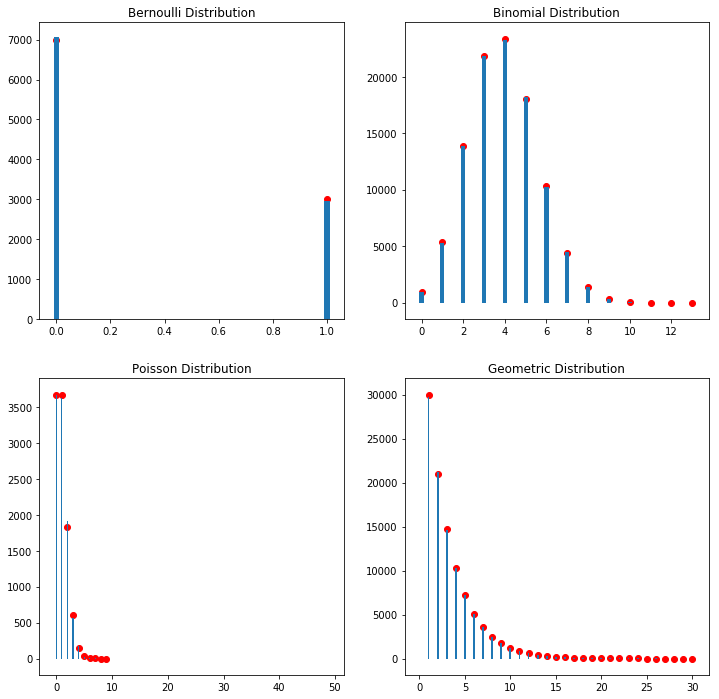

S/H

```python
figure, axis = plt.subplots(2, 2,figsize=(12,12))

def genBernoulliVar(p):
    s = acceptWithProb(p)
    if(s):
        return 1
    else:
        return 0

Y = []
p = 0.3
for i in range(10000):
    Y.append(genBernoulliVar(p))

#print(np.shape(Y))
#print('Theoretically Mean :%f'%p)
#print('Theoretically Variance: %f'%(p*(1-p)))
#print('Actual Mean %f'%np.mean(Y))
#print('Actual Variance %f'%np.var(Y))
t = np.array([0,1])
v = len(Y)*np.array([1-p,p])
axis[0,0].hist(Y,bins=[-.01,.01,0.99,1.01])
axis[0,0].scatter(t,v,color='red')
axis[0,0].set_title('Bernoulli Distribution')

# n = no. of trials
# r = no. of successes in n trials
# p = prob. of success in a trial
# q = prob. of failure (p-1) in a trial

# make a function that does n trials with p success prob.
# count the number of success in that trial (i.e r)
# append that number to array y

def nTrials(n,p):
    Z = np.zeros(n,dtype=int)
    for i in range(n):
        Z[i] = genBernoulliVar(p)
    return sum(Z)

def nCr(n,r):
    f = math.factorial
    return f(n)/(f(r)*f(n-r))

n = 13
p = 0.3
Y = []
for i in range(100000):
    Y.append(nTrials(n,p))

binarr = []
for k in range(0,n+1):
    binarr.append((float(k)-0.1))
    binarr.append((float(k)+0.1))

t = [i for i in range(n+1)]
v = len(Y)*np.array([nCr(n,i)*(p**i)*((1-p)**(n-i)) for i in range(n+1)])
#print(t)
#print(v)

#print(binarr)
#print(np.shape(Y))
#print('Theoretically Mean :%f'%(n*p))
#print('Theoretically Variance: %f'%(n*p*(1-p)))
#print('Actual Mean %f'%np.mean(Y))
#print('Actual Variance %f'%np.var(Y))
axis[0,1].hist(Y,bins=binarr)
axis[0,1].scatter(t,v,color='red')
axis[0,1].set_title('Binomial Distribution')

n = 1000
p = 0.001
Y = []

for i in range(10000):
    Y.append(nTrials(n,p))

binarr = []
for k in range(0,50):
    binarr.append((float(k)-0.1))
    binarr.append((float(k)+0.1))

#print('Theoretically Mean :%f'%(n*p))
#print('Theoretically Variance: %f'%(n*p))
#print('Actual Mean %f'%np.mean(Y))
#print('Actual Variance %f'%np.var(Y))
m = n*p
t = [i for i in range(10)]
v = len(Y)*np.array([(m**i)*np.exp(-m)/math.factorial(i) for i in range(10)])
axis[1,0].hist(Y,bins=binarr)
axis[1,0].scatter(t,v,color='red')
axis[1,0].set_title('Poisson Distribution')


def getTrialsTillSuccess(p):
    k = 0
    success = False
    while((not success) and (k<=30)):
        success = acceptWithProb(p)
        k+=1
    return k

p = 0.3
Y = []
for i in range(100000):
    Y.append(getTrialsTillSuccess(p))

binarr = []
for j in range(0,31):
    binarr.append((float(j)-0.1))
    binarr.append((float(j)+0.1))

#print(np.shape(Y))
#print('Theoretically Mean :%f'%(1/p))
#print('Theoretically Variance: %f'%((1-p)/(p*p)))
#print('Actual Mean %f'%np.mean(Y))
#print('Actual Variance %f'%np.var(Y))
t = [i for i in range(1,31,1)]
v = len(Y)*np.array([((1-p)**(i-1))*(p) for i in range(1,31,1)])
#print(binarr)
axis[1,1].hist(Y,bins=binarr)
axis[1,1].scatter(t,v,color='red')
axis[1,1].set_title('Geometric Distribution')

plt.show()
Toggle.hide_toggle()
```

### How to know which theoretical distribution does a real distribution matches closely? Q-Q Plot !!!

- Q–Q (quantile-quantile) plot is a probability plot, which is a graphical method for comparing two probability distributions by plotting their quantiles against each other.
- Below is idea how it is done:
  1. Decide interval for quantiles, say 10 and create QList = [0,10,20,30,40.....,100]
  2. D<sub>a</sub> is distribution with quantiles corresponding to QList as x = [x<sub>0</sub>, x<sub>10</sub>, x<sub>20</sub>.....,x<sub>100</sub>]
  3. D<sub>b</sub> is distribution with quantiles corresponding to QList as y = [y<sub>0</sub>, y<sub>10</sub>, y<sub>20</sub>.....,y<sub>100</sub>]
  4. Q-Q Plot is graph between x and y
  5. If the two distributions being compared are similar, the points in the Q–Q plot will approximately lie on the line y = x
  6. If the distributions are linearly related, the points in the Q–Q plot will approximately lie on a line, but not necessarily on the line y = x
  7. Q–Q plots can also be used as a graphical means of estimating parameters in a location-scale family of distributions.

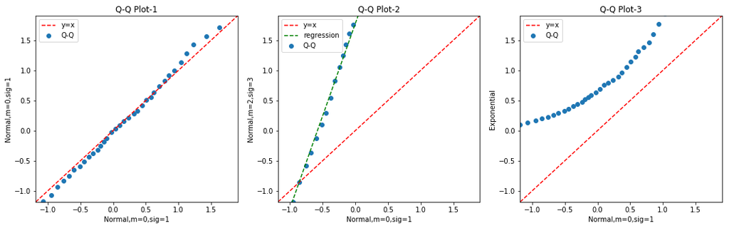

S/H

```python
import numpy as np
import matplotlib.pyplot as plt
import numpy.random as random
import Toggle
random.seed(1)

figure, axis = plt.subplots(1, 3,figsize=(18,5))

mu = 0
sigma = 1
N = 1000
Da = random.normal(mu, sigma, N)
qs = np.arange(0.1,1.0,0.025)
x = [np.quantile(Da,q) for q in qs]

mu = 0
sigma = 1
N = 1000
Db = random.normal(mu, sigma, N)
qs = np.arange(0.1,1.0,0.025)
y1 = [np.quantile(Db,q) for q in qs]

axis[0].scatter(x,y1,label='Q-Q')
axis[0].set_title('Q-Q Plot-1')
axis[0].set_xlabel('Normal,m=0,sig=1')
axis[0].set_ylabel('Normal,m=0,sig=1')
axis[0].plot([min(x),max(x)],[min(x),max(x)],color='red',linestyle='--',label='y=x')
axis[0].set_xlim(min(x),max(x))
axis[0].set_ylim(min(x),max(x))
axis[0].legend()


mu = 2
sigma = 3
N = 1000
Db = random.normal(mu, sigma, N)
qs = np.arange(0.1,1.0,0.025)
y2 = [np.quantile(Db,q) for q in qs]
axis[1].scatter(x,y2,label='Q-Q')
axis[1].set_title('Q-Q Plot-2')
axis[1].set_xlabel('Normal,m=0,sig=1')
axis[1].set_ylabel('Normal,m=2,sig=3')
axis[1].plot([min(x),max(x)],[min(x),max(x)],color='red',linestyle='--',label='y=x')
axis[1].set_xlim(min(x),max(x))
axis[1].set_ylim(min(x),max(x))
m,b = np.polyfit(x, y2, 1)
axis[1].plot(x,m*np.array(x)+b,color='green',linestyle='--',label='regression')
axis[1].legend()

mu = 1
N = 1000
Db = random.exponential(scale=1.0,size=N)
qs = np.arange(0.1,1.0,0.025)
y3 = [np.quantile(Db,q) for q in qs]
axis[2].scatter(x,y3,label='Q-Q')
axis[2].set_title('Q-Q Plot-3')
axis[2].set_xlabel('Normal,m=0,sig=1')
axis[2].set_ylabel('Exponential')
axis[2].plot([min(x),max(x)],[min(x),max(x)],color='red',linestyle='--',label='y=x')
axis[2].set_xlim(min(x),max(x))
axis[2].set_ylim(min(x),max(x))
axis[2].legend()

plt.show()
Toggle.hide_toggle()
```

### Normal Distribution and Z-score (or standard score)

$ f(x) = \frac{1}{\sigma\sqrt{2\pi}}\exp\left( -\frac{1}{2}\left(\frac{x-\mu}{\sigma}\right)^{\!2}\,\right)\\ \sigma = Standard Deviation\\ \mu = Mean\\ $

In a normal distribution:  
$68\%$ area within $\mu-\sigma$ to $\mu+\sigma$  
$95\%$ area within $\mu-2\sigma$ to $\mu+2\sigma$  
$99.7\%$ area within $\mu-3\sigma$ to $\mu+3\sigma$

$ z-score = \frac{x-\mu}{\sigma} $

In standard normal is distribution:  
$\mu$ = 0  
$\sigma$ = 1

Use of z-score:  
Suppose we conduct a census for the adult population on number of hours they sleep.  
We find that sleep duration when analyzed over entire adult population is a normal distribution with $\mu$=7.5 hours and $\sigma$=0.5.  
I sleep 8.5 hours. z-score corresponding to this value is $\frac{8.5-7.5}{0.5} = 2 $  
From the standard normal distribution graph (at z=2) I can say that I sleep for more duration than what 97.5% $(100 - \frac{5}{2})$ of the adult people sleep.

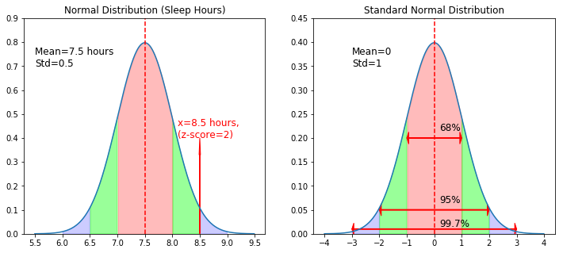

S/H

```python
from scipy.stats import norm
figure, axis = plt.subplots(1, 2,figsize=(12,5))

x = np.arange(5.5,9.5,0.01)
y = norm.pdf(x,loc=7.5,scale=0.5)
axis[0].set_ylim(0.0,0.9)
axis[0].plot(x,y)
axis[0].axvline(x=7.5,color='red',linestyle='--')
axis[0].set_title('Normal Distribution (Sleep Hours)')
axis[0].text(5.5,0.7,'Mean=7.5 hours\nStd=0.5',size=12)
#axis[0].set_xticks([-10,-7,-4,-1,2,5,8,11,14])
m = 7.5
s = 0.5
xw1 = (x>m-s) & (x<m+s)
xw2 = ((x>m-2*s) & (x<m-s)) | ((x>m+s) & (x<m+2*s))
xw3 = ((x>m-3*s) & (x<m-2*s)) | ((x>m+2*s) & (x<m+3*s))
axis[0].fill_between(x,y,where=xw1,color='#ff000044')
axis[0].fill_between(x,y,where=xw2,color='#00ff0066')
axis[0].fill_between(x,y,where=xw3,color='#0000ff33')
axis[0].arrow(8.5,0.0,0,0.4, color='red',head_length = 0.07, head_width = 0.025, length_includes_head = True)
axis[0].text(8.1,0.4,'x=8.5 hours,\n(z-score=2)',size=12,color='red')

x = np.arange(-4,4,0.01)
y = norm.pdf(x,loc=0,scale=1)
axis[1].set_ylim(0.0,0.45)
axis[1].plot(x,y)
axis[1].axvline(x=0,color='red',linestyle='--')
axis[1].set_title('Standard Normal Distribution')

#print(xw)
axis[1].arrow(-3.0,0.01,6.0,0, color='red',head_length = 0.07, head_width = 0.025, length_includes_head = True)
axis[1].arrow(3.0,0.01,-6.0,0, color='red',head_length = 0.07, head_width = 0.025, length_includes_head = True)
axis[1].arrow(-2.0,0.05,4.0,0, color='red',head_length = 0.07, head_width = 0.025, length_includes_head = True)
axis[1].arrow(2.0,0.05,-4.0,0, color='red',head_length = 0.07, head_width = 0.025, length_includes_head = True)
axis[1].arrow(-1.0,0.20,2.0,0, color='red',head_length = 0.07, head_width = 0.025, length_includes_head = True)
axis[1].arrow(1.0,0.20,-2.0,0, color='red',head_length = 0.07, head_width = 0.025, length_includes_head = True)
axis[1].text(0.2,0.015,'99.7%',color='black',size=12)
axis[1].text(0.2,0.065,'95%',color='black',size=12)
axis[1].text(0.2,0.215,'68%',color='black',size=12)

xw1 = (x>-1) & (x<1)
xw2 = ((x>-2) & (x<-1)) | ((x>1) & (x<2))
xw3 = ((x>-3) & (x<-2)) | ((x>2) & (x<3))
axis[1].fill_between(x,y,where=xw1,color='#ff000044')
axis[1].fill_between(x,y,where=xw2,color='#00ff0066')
axis[1].fill_between(x,y,where=xw3,color='#0000ff33')
axis[1].text(-3,0.35,'Mean=0\nStd=1',size=12)

plt.show()
Toggle.hide_toggle()
```

### Sampling Distribution

- A sampling distribution or finite-sample distribution is the probability distribution of a given random-sample-based statistic.
- Example of sampling distribution:
  1. Our target population is adults living in a particular city.
  2. We are interested in average height of adults in the city.
  3. It is difficult, time consuming and resource intensive to conduct a census to mesure the height of each adult in the city.
  4. We randomly select 100 adults in the city and calculate average of height for this sample.
  5. We keep on selecting such samples of 100 adults and keep calculating the average height of each sample. Obviously, averages will be different.
  6. The averages of samples will have certain distribution and it is termed as 'sampling distribution'.
  7. The statistic considered here is average but 'sampling distribution' applies to all statistic derieved from sample say median,variance,proportion etc.

### Central Limit Theorem (CLT)

- **Key take away:** Sampling distribution (for any statistic) is normal irrespective of population distribution.
- Let's say population mean is $\mu$ and population standard deviation is $\sigma$
- Now we keep drawing multiple samples of size $n$ from this population and calculate mean of each sample
- The sampling distribution i.e. distribution of these sample means, will follow a normal distribution
- The sampling distribution will be normal with mean = $\mu$ (i.e. mean of sampling distribution will be equal to population mean) and standard deviation of sampling distribution will be $\frac{\sigma}{\sqrt{n}}$
- In the above case statistic we calculated for sampling distribution is mean, it can be any other statistic and corresponding relation will hold.
- **In the example below we have a population (10000 cases) with exponential distribution. We have sampling distribution of mean. We draw samples of size 100 i.e. $n=100$**
  - Population Mean ($\mu$) = 5.0, Population Std ($\sigma$) = 5.0
  - Sampling Distribution Mean = $\mu$ = 5.0, Sampling Distribution Std = $\frac{\sigma}{\sqrt{n}}$ = $\frac{5.0}{\sqrt{100}} = \frac{5.0}{10} = 0.5$

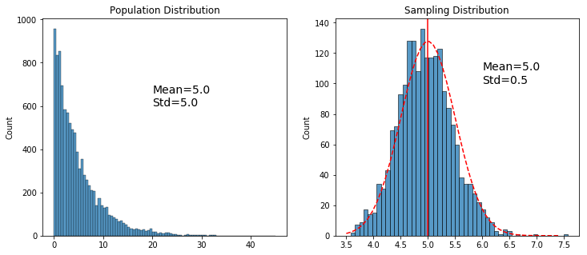

S/H

```python
import numpy as np
import matplotlib.pyplot as plt
import numpy.random as random
import seaborn as sns
from scipy.stats import norm
import Toggle
N = 10000
M = 5.0 #Population Mean
figure,axis = plt.subplots(1, 2,figsize=(12,5))
random.seed(1)
P = random.exponential(scale=M,size=N)
sns.histplot(P,kde=False,ax=axis[0])
pop_M = np.round(np.mean(P))
pop_S = np.round(np.std(P))
axis[0].text(20,600,'Mean='+str(pop_M)+'\nStd='+str(pop_S),size=14)
axis[0].set_title('Population Distribution')
samp_M_lst=[]
for i in range(2000):
    samp = random.choice(P,100)
    samp_M_lst.append(np.mean(samp))
B = 50
H = sns.histplot(samp_M_lst,kde=False,ax=axis[1],bins=B)
sampd_M = np.round(np.mean(samp_M_lst))
sampd_S = np.round(np.std(samp_M_lst),2)
axis[1].text(6,100,'Mean='+str(sampd_M)+'\nStd='+str(sampd_S),size=14)
x = np.arange(3.5,7.5,4/B)
y = norm.pdf(x,loc=5.0,scale=0.5)
axis[1].plot(x,(2000/sum(y))*y,color='red',linestyle='--')
axis[1].set_title('Sampling Distribution')
axis[1].axvline(x=5.0,color='red',linestyle='-')
#plt.hist(P)
plt.show()
Toggle.hide_toggle()
```

*It's important to realize that above ideas work for probability sampling only. Also we know simple random sample is a probability sample.*

### Confidence Interval (CI)

- We are generally interested in knowing about population statistic.Say population mean.
- But we cannot keep on drawing samples and get sampling distribution.
- We generally draw a single probability sample from the population.
- **How can we access information about population from a single random sample?**
  - Calculate unbiased point estimate (here it will be **sample mean, say$\mu$<sub>s</sub>**). Also called best estimate
  - We know that this sample mean may or may not be equal to population mean
  - But can we think how far population mean can be from sample mean?
  - **Confidence Interval = Best Estimate $\pm$ Margin of Error**
  - **Confidence Interval = Best Estimate $\pm$ (Few)*Standard Error of Point Estimate**
  - In case of above example of sample mean:
    - Best Estimate = $\mu$<sub>s</sub>
    - Standard Error of Point Estimate = $\frac{\sigma}{\sqrt{n}}$
    - CI = $\mu$<sub>s</sub> $\pm$ $f\frac{\sigma}{\sqrt{n}}$
    - With how much confidence can we say that our population mean $\mu$ will lie within CI ($\mu$<sub>s</sub> $\pm$ $f\frac{\sigma}{\sqrt{n}}$) ?
    - Say, if $f=2$ (1.96 to be exact) we cover 95% area of normal distribution centered around mean as per standard normal graph
    - But we don't know $\mu$ and we are taking this interval around $\mu$<sub>s<sub>.</sub></sub>
    - Still we say 95% confidence interval is $\mu$<sub>s</sub> $\pm$ $f\frac{\sigma}{\sqrt{n}}$
    - What it means ?
    - *It means if we keep drawing samples like this from population and keep calculating CIs in same manner for each sample, then 95% of the CIs so calculated will have population mean enclosed within them. This implies that we have 95% confidence in our experiment.*

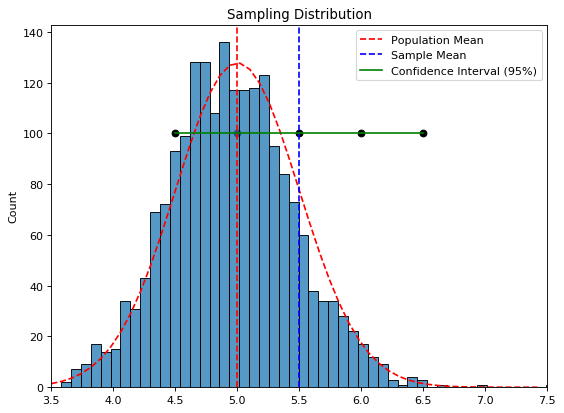

S/H

```python
B = 50
plt.figure(figsize=(8, 6), dpi=80)
H = sns.histplot(samp_M_lst,kde=False,bins=B)
sampd_M = np.round(np.mean(samp_M_lst))
sampd_S = np.round(np.std(samp_M_lst),2)
#axis.text(6,100,'Mean='+str(sampd_M)+'\nStd='+str(sampd_S),size=14)
x = np.arange(3.5,7.5,4/B)
y = norm.pdf(x,loc=5.0,scale=0.5)
plt.plot(x,(2000/sum(y))*y,color='red',linestyle='--')
plt.title('Sampling Distribution')
xL = 3.5
xM = 7.5
plt.xlim(xL,xM)
plt.axvline(x=5.0,color='red',linestyle='--',label='Population Mean')
plt.axvline(x=5.5,color='blue',linestyle='--',label='Sample Mean')
plt.axhline(y=100,xmin=(4.5-xL)/(xM-xL),xmax=(6.5-xL)/(xM-xL),color='green',label='Confidence Interval (95%)')
plt.scatter([4.5,5.0,5.5,6.0,6.5],[100,100,100,100,100],color='black')
#plt.hist(P)
plt.legend()
plt.show()
Toggle.hide_toggle()
```

### More on Confidence Interval

Previously, we estimated population mean with confidence. There are other parameters that we can estimate with confidence in following manner.

#### Estimating a Difference in Population Proportions with Confidence

What is the difference in population proportions of parents reporting that their children age 6-18 have had some swimming lessons between white children and black children?  
**Populations** - All parents of white children age 6-18 and all parents of black children age 6-18  
**Parameter of Interest** - Difference in population proportions $(p_1 - p_2)$  
Construct a 95% confidence interval for the difference in population proportions of parents reporting that their child has had swimming lessons.

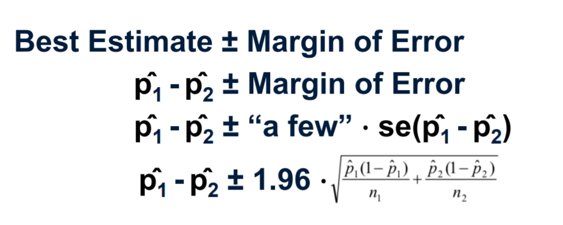

## Hypothesis Testing

**Null Hypothesis $H_0$-** Currently accepted claim. Null hypothesis is generally assumed to be true until evidence indicates otherwise.  
**Alternative Hypothesis $H_a$-** Also called research hypothesis. Involves the claim to be tested.  
Hypothesis testing result conclusion is: either we reject $H_0$ or we fail to reject $H_0$  
**Example:** It is believed that a candy machine makes candies that are an average weigh 5 grams. Now this machine is serviced. A worker claims that that the machine after maintenance makes candies that are on average weigh more than 5 grams.  
$H_0$ : $\mu \le 5g$ (Average wt. of candies is less than or equal to 5 grams)  
$H_a$ : $\mu > 5g$ (Average wt. of candies is more than 5 grams)  
Before setting up hypothesis test we need to decide:  
**Significance Level ($\alpha$)** - Let's set it as 0.05  
or  
**Confidence Level ($c = 1 - \alpha$)** - This becomes 0.95 (=1-0.05)

- Now we cannot keep weighing all candies produced by the machine as it's a never ending process. We take a sample of $n$ (=100 say) candies from the machine and get average weight of these $n$ candies.
- Let us assume that population mean is 5g ($\mu = 5g$)
- Now by CLT sampling distribution will be normal with mean $\mu$ and standard deviation $\frac{\sigma}{\sqrt{n}}$ where $\sigma$ is standard deviation of population
- But we don't even know standard deviation of population ($\sigma$). For the time being we take it to be equal to standard deviation of sample. *We will discuss more about this later*
- Say sample standard deviation is 2, so $\sigma=2$
- Mean weight of our sample of 100 candies comes out to be 5.2g, so $\mu_s=5.2g$
- Now $n=100, \mu=5, \frac{\sigma}{\sqrt{n}}=0.2,\mu_s=5.2$
- 95% area under sampling distribution graphs lies between $-\infty$ to $\mu+\frac{1.65\sigma}{\sqrt{n}}$ = $-\infty$ to 5.33
- Given the sampling distribution what is the probability that $\mu_s\ge5.2$. This is the area under graph from 5.2g to infinity. This area is p-value.
- To calculate this area we can first find, z-score of 5.2 = (5.2 - 5)/0.2 = 1. And then get value of area to the right of z-score in standard normal distribution. This is 0.159. So, p-value=0.159
- p-value can be throught as "element of suprise". Lesser the p-value for a sample statistic more surprised we are feeling w.r.t. to distribution to get that sample. The probability of getting value as extreme as 5.2 or more is 0.159 which is more than 0.05 (=$\alpha$). We are comparing with $\alpha$ because this is one tail test
- p-value$\ge \alpha$.
- 0.159$\ge 0.05$.
- Implies we are not enough surprised to get a value 5.2 g for sample mean. The sample mean of 5.2 g is fairly likely to be arising from the sampling distribution mentioned above.
- Thus, we fail to reject the null hypotheis ($H_0$) (with 95% confidence or 0.05 significance)

```
p-value corresponding to 5.2g( i.e. z-score=1) is :  0.159
The sample statistic 5.2g lies in green area and not in red area
Thus it is sufficiently probable to occur w.r.t. our expected confidence/significance level
```

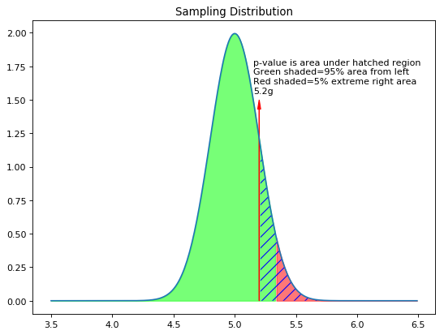

S/H

```python
from scipy.stats import norm
print('p-value corresponding to 5.2g( i.e. z-score=1) is : ', np.round(1-norm.cdf(1),3))
print('The sample statistic 5.2g lies in green area and not in red area')
print('Thus it is sufficiently probable to occur w.r.t. our expected confidence/significance level')
plt.figure(figsize=(8, 6), dpi=80)
x = np.arange(3.5,6.5,0.01)
y = norm.pdf(x,loc=5.0,scale=0.2)
plt.plot(x,y)
xw1 = (x>=5.2)
xw2 = (x<=5.33)
xw3 = (x>5.33)
plt.fill_between(x,y,where=xw2,color='#00ff0088')
plt.fill_between(x,y,where=xw3,color='#ff000088')
plt.fill_between(x,y,where=xw1,facecolor="none", hatch="//", edgecolor="b", linewidth=0.0)
plt.arrow(5.2,0.0,0,1.5, color='red',head_length = 0.07, head_width = 0.025, length_includes_head = True)
plt.text(5.15,1.55,'p-value is area under hatched region\nGreen shaded=95% area from left\nRed shaded=5% extreme right area\n5.2g')
plt.title('Sampling Distribution')
plt.show()

Toggle.hide_toggle()
```

- Keeping all the above conditions in the test to be same, let's consider situation where $\mu_s$ turns out to be 5.6g
- Corresponding z-score = (5.6-5)/0.2 = 3
- p-value = 0.0013 < 0.05
- Thus, we are quite surprised to get this value for our sample because as per assumed sampling distribution value greater than or equal to 5.6 has probability 0.0013, which is below our threshold proabibility 0.05. Thus, we shouldn't assume that our hypothesized distribution is correct.
- On graph 5.6g will lie in red region.
- Hence, we reject null hypothesis ($H_0$)with 95% confidence.

**Example of two tailed hypothesis testing:**  
It is believed that a candy machine makes candies that are an average weigh 5 grams. Now this machine is serviced. A worker claims that that the machine after maintenance no longer makes 5g candies.  
$H_0$ : $\mu = 5g$ (Average wt. of candies is equal to 5 grams)  
$H_a$ : $\mu \ne 5g$ (Average wt. of candies is not equal to 5 grams)  
95% of area (green region) lies between 4.6 to 5.4. Thus, if sample statistic goes beyond this (lies in red region), null hypothesis will be rejected  
If p-value < 0.025, then we reject the null hypothesis.  
While doing two tailed hypothesis testing with signficance level $\alpha$, we have two options mathematically

1. Calculate Z-statistic, multiply it by two because it is two tailed and if 2(Z-statistic)<$\alpha$ reject null hypothesis. Theoretically, in two tailed case, p-value is twice of Z-statistic
2. Or calculate Z-statistic, and if Z-statistic < $\alpha/2$ reject null hypothesis

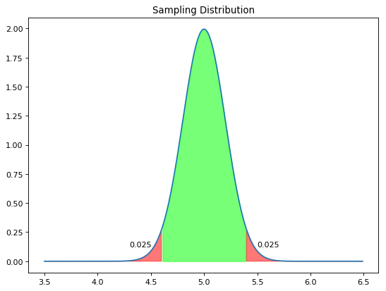

S/H

```python
from scipy.stats import norm
plt.figure(figsize=(8, 6), dpi=80)
x = np.arange(3.5,6.5,0.01)
y = norm.pdf(x,loc=5.0,scale=0.2)
plt.plot(x,y)
xw2 = (x>=(5-1.96*0.2)) & (x<=(5+1.96*0.2))
xw3 = (x<(5-1.96*0.2)) | (x>(5+1.96*0.2))
plt.fill_between(x,y,where=xw2,color='#00ff0088')
plt.fill_between(x,y,where=xw3,color='#ff000088')
plt.text(5.5,0.125,'0.025')
plt.text(4.3,0.125,'0.025')
plt.title('Sampling Distribution')
plt.show()

Toggle.hide_toggle()
```

### Population Standard Deviation is unknown

- As discussed above, we don't know population std. therefore we use sample std. instead
- We know that z-statistic (= $\frac{\mu_s - \mu}{\frac{\sigma}{\sqrt{n}}}$) follows a standard normal distribution and p-value can be calculated using standard normal curve. Here, $\sigma$ is population standard deviation.
- But t-statistic $(= \frac{\mu_s - \mu}{\frac{S}{\sqrt{n}}})$ follows a Student t-distribution with $n-1$ degrees of freedom(dof) ($\nu = n-1$) . Here, S is sample standard deviation. So, we use t-distribution to get p-value when we use sample standard deviation
- t-distribution is symmetric and bell shaped like normal distribution but has heavier tails
- Pdf of t-distribution:

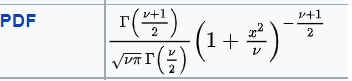

- As degrees of freedom increase Student t-distribution approaches normal distribuiton
- **Thumb Rule:**
- For n<30 we use t-statistic (small sample hypothesis testing)
- For n>30 we use z-statistic (large sample hypothesis testing)
- Thus t-statistic is generally used when sample size is small and population standard deviation is unknown
- Depending upon which distribution is used the hypothesis test is called T-test or Z-test.

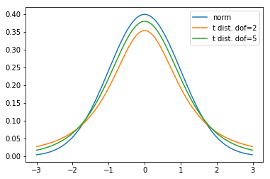

S/H

```python
from scipy.stats import t
x = np.arange(-3,3,0.01)
y = norm.pdf(x,loc=0,scale=1.0)
y1 = t.pdf(x,2)
y2 = t.pdf(x,5)
plt.plot(x,y,label='norm')
plt.plot(x,y1,label='t dist. dof=2')
plt.plot(x,y2,label='t dist. dof=5')
plt.legend()
plt.show()
Toggle.hide_toggle()
```

For large sample sizes, the sample standard deviation can be reasonable estimate of of the population standard deviation, but in such cases T-test will be give similar results to the Z-test. Therefore, it is fine to use a T-test for large samples sizes if we donot know our population variance.

### Testing for the difference of two population means (Two sample T-Test for difference of means)

Source:https://www.khanacademy.org/math/ap-statistics/xfb5d8e68:inference-quantitative-means/two-sample-t-test-means/v/two-sample-t-test-for-difference-of-means

Kaito grows tomatoes in two separate fields. When the tomatoes are ready to be picked, he is curious as to whether the sizes of his tomato plants differ between the two fields. He takes a random sample of plants from each field and measures the heights of the plants. Here is the summary of results:

| Parameter | Field A | Field B |
| --- | --- | --- |
| Mean | 1.3 | 1.6 |
| Standard Deviation | 0.5 | 0.3 |
| Number of Plants | 22 | 24 |

$H_0$ : $\mu_A = \mu_B$ (Mean size of plants in two fields is same)  
$H_a$ : $\mu_A \ne \mu_B$ (Mean size of plants in two fields is different)

Conduct a T-Test with $\alpha=0.05$  
Calculate T-Statistic  
$t = \frac{\bar{X_A} - \bar{X_B}}{\sqrt{\frac{S_A^2}{n_A} + \frac{S_B^2}{n_B}}}$  
$t = \frac{{1.3} - {1.6}}{\sqrt{\frac{0.5^2}{22} + \frac{0.3^2}{24}}}$  
$t = -2.44$  
If there is no difference is the mean according to null hypothesis: The distribution will follow of T-distribution centred at 0 with degress of freedom $\nu=21$(minimum of the two sample sizes taking conservative approach)

```
Area under graph (pink region, because two tailed hypothesis test), p-value = 0.0236
```

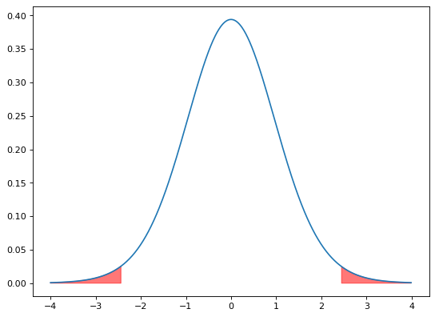

```python
from scipy.stats import t
import matplotlib.pyplot as plt
import numpy as np
plt.figure(figsize=(8, 6), dpi=80)
x = np.arange(-4.0,4.0,0.01)
y = t.pdf(x,21)
xw1 = ((x>=2.44) | (x<=-2.44))
plt.fill_between(x,y,where=xw1,color='#ff000088')
plt.plot(x,y)
print('Area under graph (pink region, because two tailed hypothesis test), p-value =', 2*np.round(t.cdf(-2.44,21),4))
plt.show()
```

0.0236 < 0.05  
p-value < $\alpha$  
Thus we reject the null hypotheis

### Pearson's Chi Squared Test (Goodness of Fit Test)

Source:https://www.youtube.com/watch?v=2QeDRsxSF9M

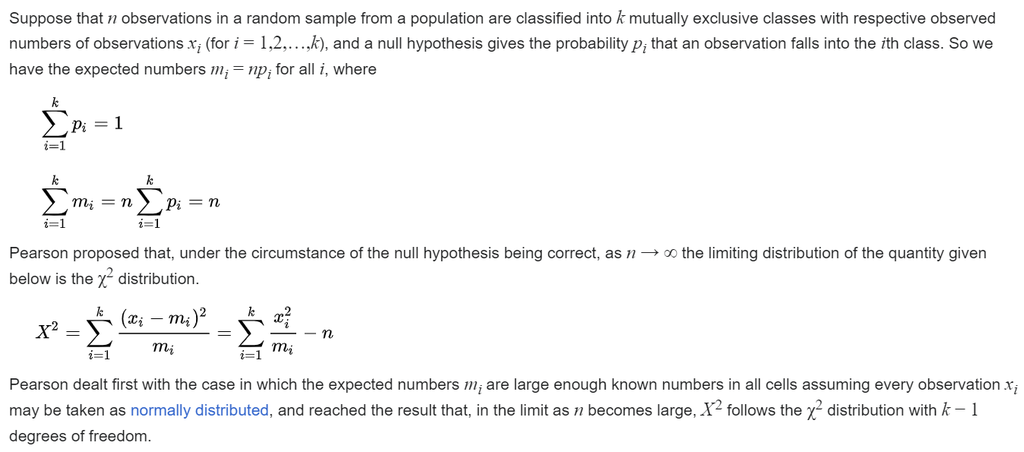

I want to buy a restaurant. So, I approach a restaurant owner ask him what is the distribution of customer that come on each of these days of week. He gives me a distribution in terms of percentage. Then I make an observation for a full week and take count of customers coming on each day.

| Day | Mon | Tue | Wed | Thu | Fri | Sat | Total |
| --- | --- | --- | --- | --- | --- | --- | --- |
| Expected % | 10 | 10 | 15 | 20 | 30 | 15 | 100% |
| Observed | 30 | 14 | 34 | 45 | 57 | 20 | 200 |
| Expected Observation | 20 | 20 | 30 | 40 | 60 | 30 | 200 |

$H_0$ : Owner's distribution is correct  
$H_a$ : Owner's distribution is not correct

For test we keep signficance level, $\alpha$=0.05

$X^2 = \frac{(30-20)^2}{20} + \frac{(14-20)^2}{20} + \frac{(34-30)^2}{30} + \frac{(45-40)^2}{40} + \frac{(57-60)^2}{60} + \frac{(20-30)^2}{30} = 11.44$  
Though $n$ here is 200, still we use $\chi^2$ distribution  
Degrees of Freedom, k = 6 - 1 = 5, why degrees of freedom is 5 not 6 because 6th observation can be deduced when 5 observations are known. Also, look at the formula, degrees of feedom is one minus number of classes. Here classes are 6.

```
Area under graph (pink region), p-value = 0.0433
```

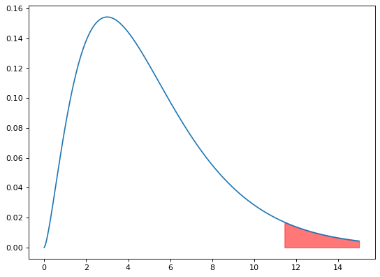

```python
from scipy.stats import chi2
import matplotlib.pyplot as plt
import numpy as np
plt.figure(figsize=(8, 6), dpi=80)
x = np.arange(0,15,0.01)
y = chi2.pdf(x,df=5)
xw1 = (x>=11.44)
plt.fill_between(x,y,where=xw1,color='#ff000088')
plt.plot(x,y)
print('Area under graph (pink region), p-value =', np.round(1-chi2.cdf(11.44,df=5),4))
plt.show()
```

Since p-value < $\alpha$ we reject the null hypothesis

### ANOVA (Analysis of Variance): Hypothesis Test with F-Statistic

Source:https://www.youtube.com/watch?v=Xg8_iSkJpAE&list=PL7FCBC940F3067FD0&index=13  
Source: https://www.youtube.com/watch?v=ITf4vHhyGpc

We have already seen how to test if there is difference in two population means.  
But what if we want to test whether there is difference in population means of more than two populations.  
We can use ANOVA: F-Test  
Set up an experiment to determine whether beverage that people drink affects their reaction time.  
We set up an experiment with three groups of people. 5 people in each group.  
Each group is given different beverage to drink i.e. water, sugary fruit juice and coffee. Below is the result.

|  | Water(1) | Sugary Juice(2) | Coffee(3) |
| --- | --- | --- | --- |
|  | 29 | 28 | 25 |
|  | 30 | 29 | 28 |
|  | 31 | 27 | 29 |
|  | 31 | 30 | 27 |
|  | 29 | 29 | 29 |
| Mean | 30.0 | 28.6 | 27.6 |

Here $m$=Number of groups = 3  
And $n$=Number of samples in each group = 5  
$\bar{X_1} = (29+30+31+31+29)/5 = 30.0$  
$\bar{X_2} = (28+29+27+30+29)/5 = 28.6$  
$\bar{X_3} = (25+28+29+27+29)/5 = 27.6$  
Grand Mean $= \bar{\bar{X}} = (29+30+31+31+29+28+29+27+30+29+25+28+29+27+29)/15 = 28.73$

$H_0$ : $\mu_1 = \mu_2 = \mu_3$  
$H_a$ :Population means are not equal

$\alpha = 0.05 $ (significance level)

**SST (Sum of Squares Total):**  
Degrees of freedom $(df)$ = $m.n-1$  
$(x_k-\bar{\bar{X}})^2$ where $k$ varies form 1 to 15. All observations in each group are included in this sum. So, it is called SST

**SSW (Sum of Squares Within):**  
Degrees of freedom = $m.(n-1)$  
$\sum_{i=1}^{3}{\sum_{j=1}^{5}(x_{ij}-\bar{X_i}})^2$. In this sum $i$ denotes class,$j$ denotes sample within the class.So, it is called SSW

**SSB (Sum of Squares Between):**  
Degrees of freedom = $m-1$  
$\sum_{i=1}^{3}5(\bar{X_i}-\bar{\bar{X}})^2$. In this sum $i$ denotes class and we are taking square of difference between class mean and grand mean. This is being done for each sample of the class, hence multiplication by 5. So, it is called SSB

$df_{SST} = df_{SSW} + df_{SSB}$  
$m.n-1 = (mn-m)+ (m-1)$  
Also  
SST = SSW + SSB

##### Calculating same below

```python
X1 = [29,30,31,31,29]
X2 = [28,29,27,30,29]
X3 = [25,28,29,27,29]
X1_m = np.mean(X1) #Class 1 Mean
X2_m = np.mean(X2) #Class 2 Mean
X3_m = np.mean(X3) #Class 3 Mean
X = X1 + X2 + X3 # Full array
X_m = (sum(X1)+sum(X2)+sum(X3))/15 # Grand mean
print("Class 1 Array: ",X1)
print("Class 1 Mean: ",X1_m)
print("Class 2 Array: ",X2)
print("Class 2 Mean: ",X2_m)
print("Class 3 Array: ",X3)
print("Class 3 Mean: ",X3_m)
print("Full Array: ",X)
print("Grand Mean: ",np.round(X_m,4))

SST = sum((np.array(X)-X_m)**2)
print('SST = ', np.round(SST,4))

SSW = sum((np.array(X1)-X1_m)**2) + sum((np.array(X2)-X2_m)**2) + sum((np.array(X3)-X3_m)**2)
print('SSW = ', np.round(SSW,4))

SSB = 5*(X1_m-X_m)**2 + 5*(X2_m-X_m)**2 + 5*(X3_m-X_m)**2
print('SSB = ', np.round(SSB,4))

print('SSW + SSB = ', np.round(SSW+SSB,4))
```

```
Class 1 Array:  [29, 30, 31, 31, 29]
Class 1 Mean:  30.0
Class 2 Array:  [28, 29, 27, 30, 29]
Class 2 Mean:  28.6
Class 3 Array:  [25, 28, 29, 27, 29]
Class 3 Mean:  27.6
Full Array:  [29, 30, 31, 31, 29, 28, 29, 27, 30, 29, 25, 28, 29, 27, 29]
Grand Mean:  28.7333
SST =  34.9333
SSW =  20.4
SSB =  14.5333
SSW + SSB =  34.9333
```

##### F-Distribution

This distribution is the ratio of two $\chi^2$ distribution. And we use it to calculate F-statistic for the F-test.

##### F-Test

F Statistic = $\frac{\frac{SSB}{m-1}}{\frac{SSW}{m.(n-1)}}$

F statistc is high, means numerator is larger than denominator. It means 'variance between classes' is a major contributor to 'total variance' as compared to 'within class variance'. If F-Statistic is high, p-value will be low, this means that we will be more surprised w.r.t. null hypothesis and our chances of rejecting null hypothesis will increase. Rejecting null hypothesis means we say that we don't believe that means are equal because variance between classes is high.

```python
n = 5
m = 3
F_statistic = (SSB/(m-1))/(SSW/(m*(n-1)))
print(F_statistic)
```

```
4.274509803921564
```

```
Area under graph (pink region) p-value = 0.0397
```

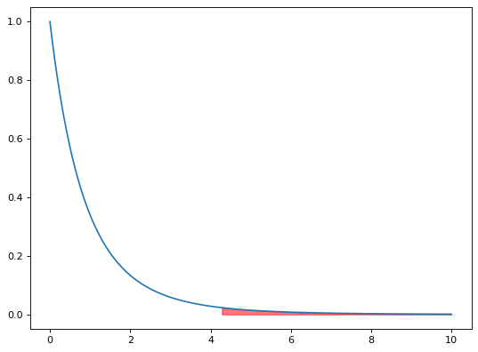

```python
from scipy.stats import f
import matplotlib.pyplot as plt
import numpy as np
plt.figure(figsize=(8, 6), dpi=80)
x = np.arange(0,10,0.01)
# Degrees of freedom Numerator, dfn = m-1
#Degrees of freedom Denominator, dfd = m(n-1)
y = f.pdf(x,dfn=(m-1),dfd=(m*(n-1)))
xw1 = (x>=F_statistic)
plt.fill_between(x,y,where=xw1,color='#ff000088')
plt.plot(x,y)
print('Area under graph (pink region) p-value =', np.round(1-f.cdf(F_statistic,dfn=(m-1),dfd=m*(n-1)),4))
plt.show()
```

Since p-value < $\alpha$ we reject the null hypothesis  
That is we reject the hypothesis that mean response time for all beverages is equal.